# Processing Malaria Genomics Project Pf3k v5

Stuart Lee

2016-06-22

# 1 Introduction

Here we pre-process the Malaria Genomics Project Pf3k project data for both IBD analysis within `isoRelate` and to construct a processed ground truth data set using the known mixture clones present in the data.

Up to this point the following steps have been applied to the VCF files obtained from Pf3k website.

For each chromosome VCF file we applied the following filters using `vcftools`:

- Remove indels
- Keep only biallelic single nucleotide variants on 14 nuclear chromosomes.
- Remove variants if they lie in a Subtelomeric hypervariable or repeat region, or in an internal hypervariable or centromere region.
- Remove variants with a log odds score of being true variant versus a false variant of 0 or less. (Following the Malaria Genomics guidelines)

After we have processed each chromosome VCF we concatenate them together.

```bash
set -e
vcfdir=/path/to/malaria_gen5/vcf_files
outdir=./raw_data/
tempdir=~/tmp/
# step 1, select only SNPs + VQSLOD > 0, regiontype = core
vcf_chrom=$(find $vcfdir -regex ".*\.*[0-9][0-9]_v3.*.vcf.gz" | sort -u)

for chr in $vcf_chrom
do
    (stem=$(basename $chr .vcf.gz)
    echo $stem
    vcftools --gzvcf $chr \
    --remove-indels \
    --min-alleles  2 \
    --max-alleles 2 \
    --remove-filtered-all \
    --recode \
    --recode-INFO-all \
    --stdout | bgzip -c > ${tempdir}${stem}.vcf.gz
    tabix -p vcf ${tempdir}${stem}.vcf.gz) &

done
wait

filtered_vcf=$(find $tempdir -name "*.vcf.gz" | sort -u)

bcftools concat -Oz -o ${outdir}malaria_gen5_biallelic_snps.vcf.gz $filtered_vcf
```

Then we convert the VCF to the GDS format keeping only the tags of interest.

```r
library(SeqArray)
vcf_file <- "raw_data/malaria_gen5_biallelic_snps.vcf.gz"

vcf_header <- seqVCF_Header(vcf_file)

# recode header format for AD from R to .
vcf_header$format$Number[vcf_header$ID == "AD"] <- "."

# info columns to keep
info.import <- c("AC", "AF", "AN", "BaseQRankSum", "ClippingRankSum",
                 "DP", "FS", "InbreedingCoeff", "MQ", "MQRankSum",
                 "QD", "ReadPosRankSum",
                 "SOR", "VQSLOD", "SNPEFF_AMINO_ACID_CHANGE",
                 "SNPEFF_CODON_CHANGE", "SNPEFF_EFFECT", "SNPEFF_EXON_ID",
                 "SNPEFF_FUNCTIONAL_CLASS", "SNPEFF_GENE_BIOTYPE",
                 "SNPEFF_GENE_NAME", "SNPEFF_IMPACT", "SNPEFF_TRANSCRIPT_ID")

# format columns to keep
fmt.info <- c("AD", "DP", "GQ", "GT", "PL", "PGT",  "PID")

seqVCF2GDS(vcf_file, "processed_data/malaria_gen5.gds",
           header = vcf_header,
           info.import = info.import,
           fmt.import = fmt.info)
```

We now are ready to use the GDS file for analysis in R.

```r
suppressPackageStartupMessages(library(SeqArray))
suppressPackageStartupMessages(library(dplyr))
suppressPackageStartupMessages(library(moimix))

# use readonly = FALSE to add sample annotations
mgen <- seqOpen("processed_data/malaria_gen5.gds", readonly = FALSE)
```

The final variant set consists of 1057870 SNVs segregating by chromosome as follows:

```r
knitr::kable(data.frame(chr = seqGetData(mgen, "chromosome") )
             %>% count(chr),
             caption = "SNV counts by chromosome")
```

SNV counts by chromosome

| chr | n |
| --- | --- |
| Pf3D7_01_v3 | 21475 |
| Pf3D7_02_v3 | 35168 |
| Pf3D7_03_v3 | 43199 |
| Pf3D7_04_v3 | 45051 |
| Pf3D7_05_v3 | 61349 |
| Pf3D7_06_v3 | 55371 |
| Pf3D7_07_v3 | 57980 |
| Pf3D7_08_v3 | 58741 |
| Pf3D7_09_v3 | 73279 |
| Pf3D7_10_v3 | 72528 |
| Pf3D7_11_v3 | 98484 |
| Pf3D7_12_v3 | 99409 |
| Pf3D7_13_v3 | 151941 |
| Pf3D7_14_v3 | 183895 |

We have also processed the sample metadata to see how the samples segregate by geography. Samples with missing country variable correspond to the lab-strains from the complexity of infection and genetic crosses study.

```r
# load metadata
library(readr)
mgen_meta <- read_rds("processed_data/mgen_clean.rds")
```

There are 2512 total field isolates and the dataset can be broadly grouped into three broader geographic locations:

1. West Africa: Senegal, The Gambia, Guinea, Mali, Ghana, Nigeria
2. Central Africa: DR Congo, Malawi
3. South-east Asia: Bangladesh, Cambodia, Vietnam, Thailand, Myanmar, Laos

```r
west_africa <- c("The Gambia", "Ghana", "Guinea", "Mali", "Nigeria", "Senegal")
central_africa <- c("DR of the Congo", "Malawi")
se_asia <- c("Bangladesh", "Cambodia", "Laos", "Myanmar", "Thailand", "Vietnam")

mgen_meta$region <- NA
mgen_meta$region[mgen_meta$country %in% west_africa] <- "West Africa"
mgen_meta$region[mgen_meta$country %in% central_africa] <- "Central Africa"
mgen_meta$region[mgen_meta$country %in% se_asia] <- "SE Asia"

field_isolates <- mgen_meta %>% filter(!is.na(country))

knitr::kable(field_isolates %>% count(region, country, site))
```

| region | country | site | n |
| --- | --- | --- | --- |
| Central Africa | DR of the Congo | Kinshasa | 113 |
| Central Africa | Malawi | Chikwawa | 317 |
| Central Africa | Malawi | Zomba | 52 |
| SE Asia | Bangladesh | Ramu | 50 |
| SE Asia | Cambodia | Pailin | 84 |
| SE Asia | Cambodia | Preah Vihear | 104 |
| SE Asia | Cambodia | Pursat | 235 |
| SE Asia | Cambodia | Ratanakiri | 147 |
| SE Asia | Laos | Attapeu | 85 |
| SE Asia | Myanmar | Bago Division | 60 |
| SE Asia | Thailand | Mae Sot | 106 |
| SE Asia | Thailand | Ranong | 20 |
| SE Asia | Thailand | Sisakhet | 22 |
| SE Asia | Vietnam | Bu Dang | 1 |
| SE Asia | Vietnam | Bu Gia Map | 64 |
| SE Asia | Vietnam | Phuoc Long | 32 |
| West Africa | Ghana | Kassena | 549 |
| West Africa | Ghana | Kintampo | 68 |
| West Africa | Guinea | Nzerekore | 100 |
| West Africa | Mali | Bandiagara | 9 |
| West Africa | Mali | Faladje | 36 |
| West Africa | Mali | Kolle | 51 |
| West Africa | Nigeria | Ilorin | 5 |
| West Africa | Senegal | Thies | 133 |
| West Africa | Senegal | Velingara | 4 |
| West Africa | The Gambia | GM_Coastal | 65 |

```r
# add metadata to GDS file
# first reorder according to sample.id
mgen_meta <- mgen_meta %>% arrange(sample)
if(cnt.gdsn(index.gdsn(mgen, "sample.annotation")) != 4) {
    add.gdsn(index.gdsn(mgen, "sample.annotation"),
             name = "acc", val = mgen_meta$acc)
    add.gdsn(index.gdsn(mgen, "sample.annotation"),
             name = "region", val =mgen_meta$region)
    add.gdsn(index.gdsn(mgen, "sample.annotation"),
             name = "country",val = mgen_meta$country)
    add.gdsn(index.gdsn(mgen, "sample.annotation"),
             name = "site", val = mgen_meta$site)
}
```

# 2 Additional sample and SNP filtering

Prior to estimating the minor allele frequencies within a region and obtaining a final set of SNPs and samples, we need to ensure we are confident in the SNP set we have obtained and that samples are of high-quality. Although these samples have been processed by there still might be samples that are poorly genotyped and SNVs that aren’t polymorphic globally or within the subpopulations.

We first look at the various quality metrics provided by the Haplotype Caller for variant annotated in the VCF files. Of particular interest is the QD MQRanksum, and SOR tags.

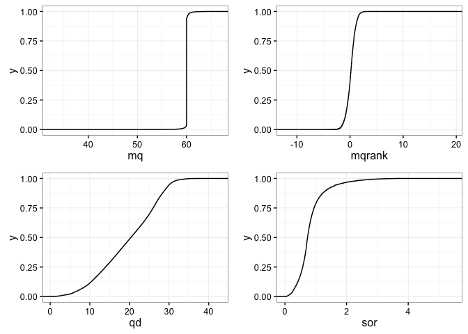

```r
library(ggplot2)
library(grid)
theme_set(theme_bw())
gatk_df <- data.frame(variant.id = seqGetData(mgen, "variant.id"),
                      chr = seqGetData(mgen, "chromosome"),
                      mq =  seqGetData(mgen, "annotation/info/MQ"),
                      mqrank = seqGetData(mgen, "annotation/info/MQRankSum"),
                      qd = seqGetData(mgen, "annotation/info/QD"),
                      sor = seqGetData(mgen, "annotation/info/SOR"))

grid.newpage()
pushViewport(viewport(layout = grid.layout(2, 2)))

print(ggplot(gatk_df, aes(x = mq)) + stat_ecdf(),
      vp = viewport(layout.pos.row = 1, layout.pos.col = 1))
print(ggplot(gatk_df, aes(x = mqrank)) + stat_ecdf(),
      vp = viewport(layout.pos.row = 1, layout.pos.col = 2))
print(ggplot(gatk_df, aes(x = qd)) + stat_ecdf(),
      vp =  viewport(layout.pos.row = 2, layout.pos.col = 1))
print(ggplot(gatk_df, aes(x =  sor)) + stat_ecdf(),
      vp =  viewport(layout.pos.row = 2, layout.pos.col = 2))
```

```r
# filter based on field samples
# filter based on qd > 15, sor < 1, mqrank > -2 , MQ > 50

v_ids <- (gatk_df %>% filter(qd > 15, mq > 50, sor < 1,
                             mqrank > -2 | is.na(mqrank)))$variant.id
```

We see that all variants are supported by high residual mean square mapping qualities over all samples. The distribution of MQRankSum scores (which is only computed at heterozygous sites) is centred at 0 with a fat right tail. For this tag only negative scores are useful since that indicates that the mapping quality for the alternate allele is low compared to the reference allele. The QD distribution is relatively symmetric and centred at around 20, most variants have relatively good ratios of average quality to average depth. The SOR tag is an odds ratio score to detect strand bias from a 2 x 2 contingency table using the strands and alt/ref allele counts as the rows and columns respectively.

We apply some hard filters to all samples:

- QD score > 15
- SOR < 1
- MQRankSum > -2 (allowed to be missing for sites with heterozygous calls)
- MQ > 50

This leaves approximately 561695 SNVs.

Of the remaining SNVs we then split the data by country and apply the following filters

To do this we construct a nested list data structure of where that consist of three lists per region and lists containing the following for each country:

- sample identifiers meeting our criteria
- SNP identifiers meeting our criteria
- Fws estimates
- MAF estimates

We also plot the ECDFs for all these estimates.

```
## ## Now running The Gambia estimates# of selected samples: 65
## # of selected variants: 561,695
## # of selected variants: 62,094
## # of selected variants: 46,576
## # of selected samples: 57
## # of selected variants: 46,576
```

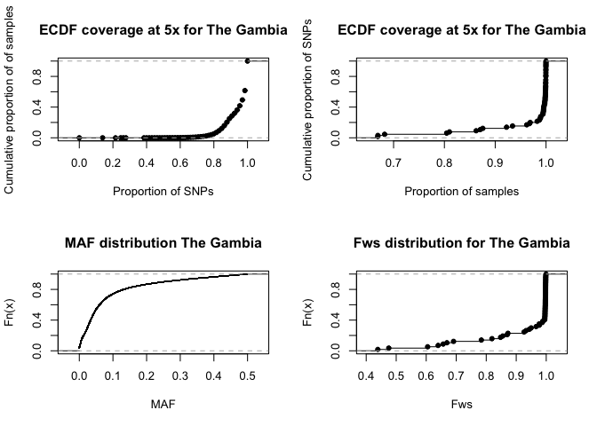

```
## # of selected samples: 2,640
## # of selected variants: 1,057,870
## ## Now running Guinea estimates# of selected samples: 100
## # of selected variants: 561,695
## # of selected variants: 102,662
## # of selected variants: 101,425
## # of selected samples: 100
## # of selected variants: 101,425
```

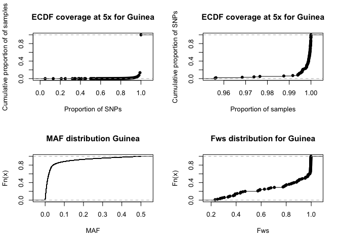

```
## # of selected samples: 2,640
## # of selected variants: 1,057,870
## ## Now running Ghana estimates# of selected samples: 617
## # of selected variants: 561,695
## # of selected variants: 307,330
## # of selected variants: 258,289
## # of selected samples: 563
## # of selected variants: 258,289
```

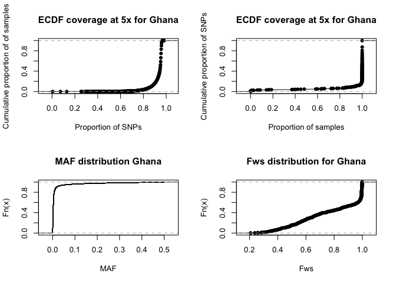

```
## # of selected samples: 2,640
## # of selected variants: 1,057,870
## ## Now running Mali estimates# of selected samples: 96
## # of selected variants: 561,695
## # of selected variants: 84,512
## # of selected variants: 46,668
## # of selected samples: 84
## # of selected variants: 46,668
```

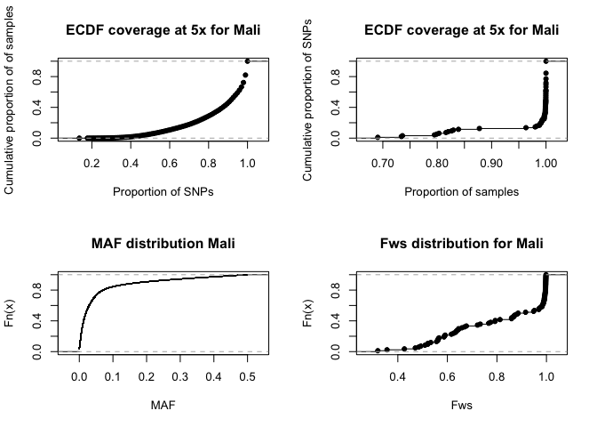

```
## # of selected samples: 2,640
## # of selected variants: 1,057,870
## ## Now running Nigeria estimates# of selected samples: 5
## # of selected variants: 561,695
## # of selected variants: 16,283
## # of selected variants: 12,553
## # of selected samples: 4
## # of selected variants: 12,553
```

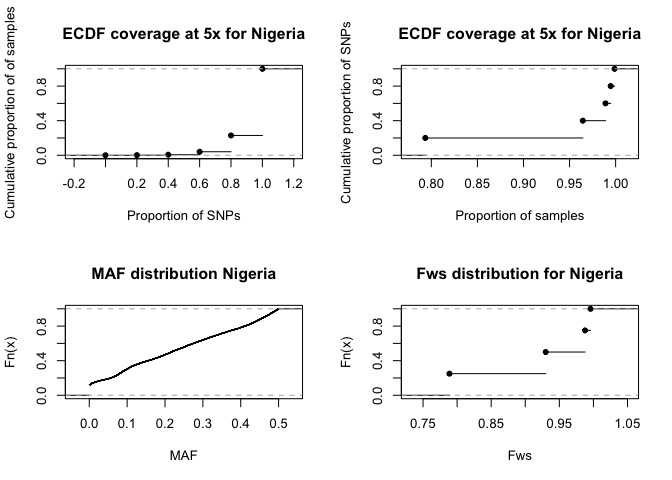

```
## # of selected samples: 2,640
## # of selected variants: 1,057,870
## ## Now running Senegal estimates# of selected samples: 137
## # of selected variants: 561,695
## # of selected variants: 84,496
## # of selected variants: 52,664
## # of selected samples: 131
## # of selected variants: 52,664
```

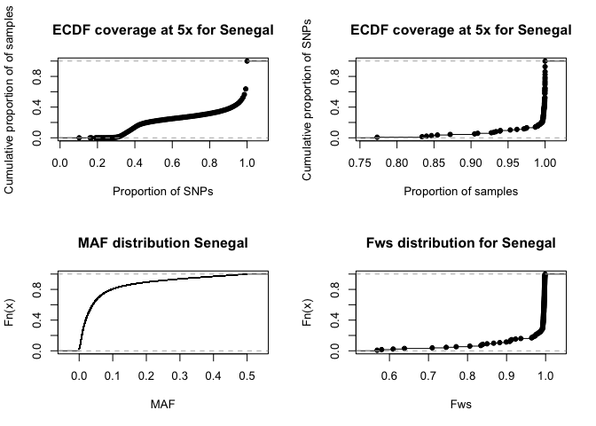

```
## # of selected samples: 2,640
## # of selected variants: 1,057,870
## ## Now running Thailand estimates# of selected samples: 148
## # of selected variants: 561,695
## # of selected variants: 44,232
## # of selected variants: 40,502
## # of selected samples: 140
## # of selected variants: 40,502
```

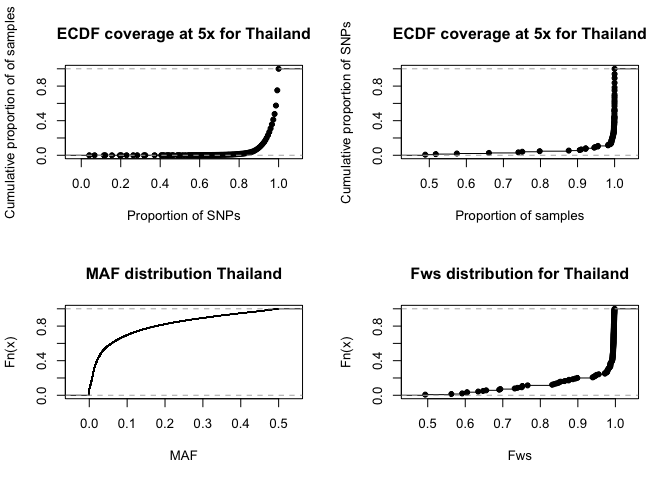

```
## # of selected samples: 2,640
## # of selected variants: 1,057,870
## ## Now running Cambodia estimates# of selected samples: 570
## # of selected variants: 561,695
## # of selected variants: 70,489
## # of selected variants: 58,987
## # of selected samples: 521
## # of selected variants: 58,987
```

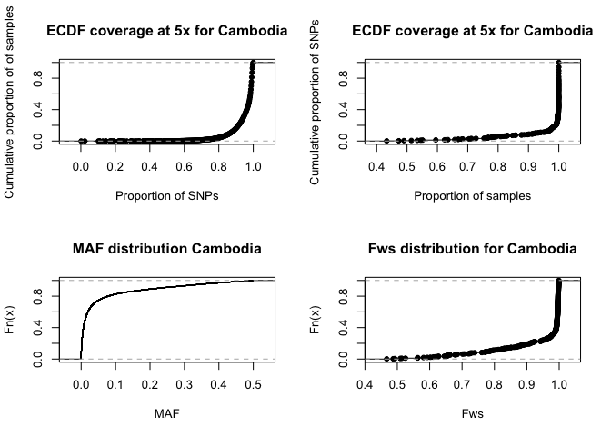

```
## # of selected samples: 2,640
## # of selected variants: 1,057,870
## ## Now running Bangladesh estimates# of selected samples: 50
## # of selected variants: 561,695
## # of selected variants: 49,140
## # of selected variants: 34,708
## # of selected samples: 45
## # of selected variants: 34,708
```

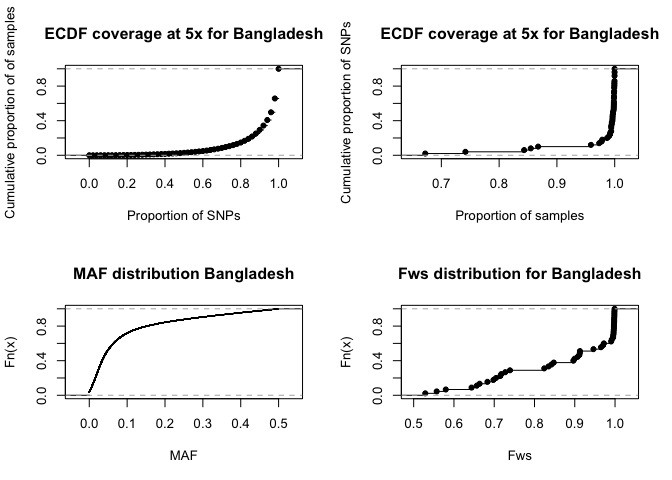

```
## # of selected samples: 2,640
## # of selected variants: 1,057,870
## ## Now running Vietnam estimates# of selected samples: 97
## # of selected variants: 561,695
## # of selected variants: 44,524
## # of selected variants: 42,011
## # of selected samples: 96
## # of selected variants: 42,011
```

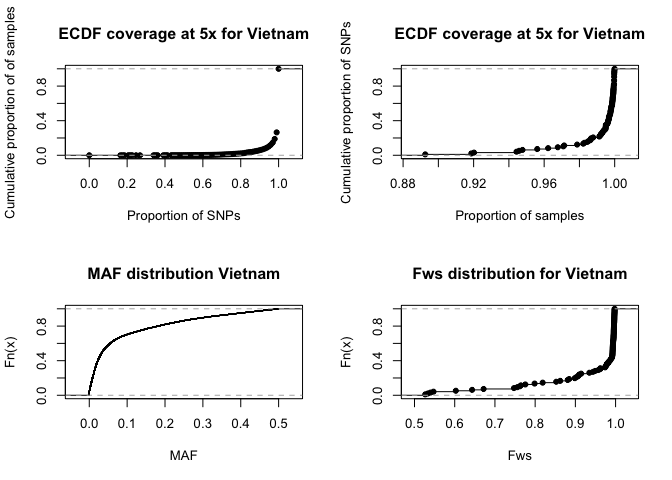

```
## # of selected samples: 2,640
## # of selected variants: 1,057,870
## ## Now running Myanmar estimates# of selected samples: 60
## # of selected variants: 561,695
## # of selected variants: 37,092
## # of selected variants: 33,179
## # of selected samples: 57
## # of selected variants: 33,179
```

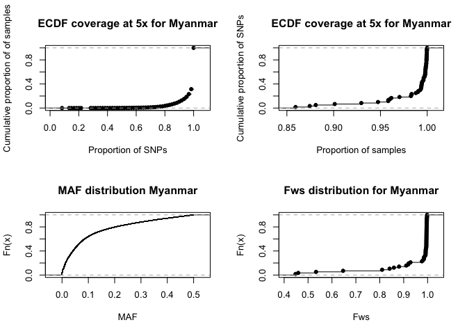

```
## # of selected samples: 2,640
## # of selected variants: 1,057,870
## ## Now running Laos estimates# of selected samples: 85
## # of selected variants: 561,695
## # of selected variants: 48,448
## # of selected variants: 46,447
## # of selected samples: 84
## # of selected variants: 46,447
```

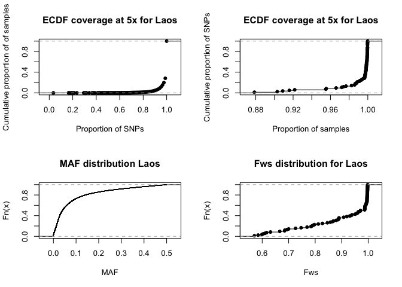

```
## # of selected samples: 2,640
## # of selected variants: 1,057,870
## ## Now running Malawi estimates# of selected samples: 369
## # of selected variants: 561,695
## # of selected variants: 156,759
## # of selected variants: 154,265
## # of selected samples: 357
## # of selected variants: 154,265
```

[2 more figures not shown]

```
## # of selected samples: 2,640
## # of selected variants: 1,057,870
```

```r
mgen_stats <- list()

for (location in unique(field_isolates$region)) {
  mgen_stats[[location]] <- list()
  country_unique <- unique(field_isolates$country[field_isolates$region == location])
  for (country in country_unique) {
    mgen_stats[[location]][[country]] <- list()
    # apply filter first pass
    samples <- field_isolates$sample[field_isolates$country == country]
    # filter first
    cat(paste("## Now running", country, "estimates"))
    seqSetFilter(mgen, sample.id = samples, variant.id = v_ids)
    # SNVs covered to 5 bases overall samples in country
    # first pass at computing MAF
    maf_init <- getMAF(mgen)
    # exclude variants that have MAF <= 0 and snp_5x < 0.9
    variants_step1 <- v_ids[maf_init > 0]
    seqSetFilter(mgen, variant.id = variants_step1)

    snp_5x <- perSiteCoverageBySample(mgen, 5L)
    variants_step2 <- variants_step1[snp_5x > 0.9]
    seqSetFilter(mgen, variant.id = variants_step2)

    # sample exclusions
    sample_5x <- perSiteCoverageBySNP(mgen, 5L)
    # samples to keep
    samples_step1 <- samples[sample_5x >= 0.9]

    seqSetFilter(mgen, sample.id = samples_step1, variant.id = variants_step2)
    # maf final
    maf_final <- getMAF(mgen)
    variants_step3 <- seqGetData(mgen, "variant.id")
    # estimate Fws on subset region
    # fws_final
    fws_final <- getFws(mgen)

    maf_filter <- variants_step3[maf_final > 0.01]
    # collect data
    mgen_stats[[location]][[country]]$samples <- samples_step1
    mgen_stats[[location]][[country]]$snps <- maf_filter
    mgen_stats[[location]][[country]]$fws <- fws_final
    # create plots
    par(mfrow = c(2,2))

    plot(ecdf(snp_5x),
     xlab = "Proportion of SNPs",
     ylab = "Cumulative proportion of of samples",
     main = paste("ECDF coverage at 5x for", country))

    plot(ecdf(sample_5x),
     xlab = "Proportion of samples",
     ylab = "Cumulative proportion of SNPs",
     main= paste("ECDF coverage at 5x for", country))

    plot(ecdf(maf_final),
         xlab =  "MAF",
         main = paste("MAF distribution", country))

    plot(ecdf(fws_final),
         xlab = "Fws",
         main = paste("Fws distribution for", country))
    # reset filter
    seqSetFilter(mgen)
  }
}
```

The following table presents the counts of SNPs and samples for each regions, that fit the above filters.

```r
filter_results <- lapply(mgen_stats,
                         function(country_list)  {
                           data.frame(country = names(country_list),
                                      bind_rows(lapply(country_list,
                                                       function(info) {
                                                         data.frame(n_snps = length(info$snps),
                                                                    n_samples = length(info$samples))
                                                       })))})
knitr::kable(left_join(field_isolates %>%
                         distinct(region, country)  %>%
                         select(region, country),
                       bind_rows(filter_results)))
```

| region | country | n_snps | n_samples |
| --- | --- | --- | --- |
| West Africa | The Gambia | 38307 | 57 |
| West Africa | Guinea | 60755 | 100 |
| SE Asia | Thailand | 30498 | 140 |
| West Africa | Ghana | 40050 | 563 |
| SE Asia | Cambodia | 30768 | 521 |
| West Africa | Mali | 30649 | 84 |
| SE Asia | Bangladesh | 29978 | 45 |
| Central Africa | Malawi | 53300 | 357 |
| SE Asia | Vietnam | 32628 | 96 |
| SE Asia | Myanmar | 27834 | 57 |
| SE Asia | Laos | 39008 | 84 |
| Central Africa | DR of the Congo | 40119 | 104 |
| West Africa | Nigeria | 10748 | 4 |
| West Africa | Senegal | 39803 | 131 |

```r
region_results <- lapply(mgen_stats,
                         function(country_list)
                           lapply(country_list, function(info) info$snps))

# remove Nigieria as sample size is very low
wa_countries <- names(region_results[[1]])
region_results[[1]] <- region_results[[1]][wa_countries != "Nigeria"]

by_region_snps <- lapply(region_results,
                         function(region) Reduce("unique", region))

knitr::kable(unlist(lapply(by_region_snps, length)) %>% data.frame)
```

|  | . |
| --- | --- |
| West Africa | 38307 |
| SE Asia | 30498 |
| Central Africa | 53300 |

```r
# extract samples
region_results_samples <- lapply(mgen_stats,
                            function(country_list) lapply(country_list,
                                                          function(info) info$samples))
region_results_samples[[1]] <- region_results_samples[[1]][wa_countries != "Nigeria"]

by_region_samples <- lapply(region_results_samples,
                            function(region) unlist(region, use.names = FALSE))
```

# 3 Constructing three region specific data subsets

For the IBD analysis we require filters on the variants to ensure the SNPs have high enough MAFs and to annotate samples that are putatively clonal.

To do this we perform the following steps:

1. Subset the calls by geographic region defined above.
2. Use the $F_{ws}$ metric estimated above to annotate samples as either single clones or multiple clone infections. We use this for a quick proxy for multiple infections, before assessing this in more detail using `moimix`.
3. Estimate the MAFs directly from read-count data within a region. We can then look at the overall estimated MAF distributions using our combined variant sets.

We also save the PED and MAP file, annotations, as an R objects to speed up write-out.

```
## # of selected samples: 935
## # of selected variants: 38,307
## ## West Africa
```

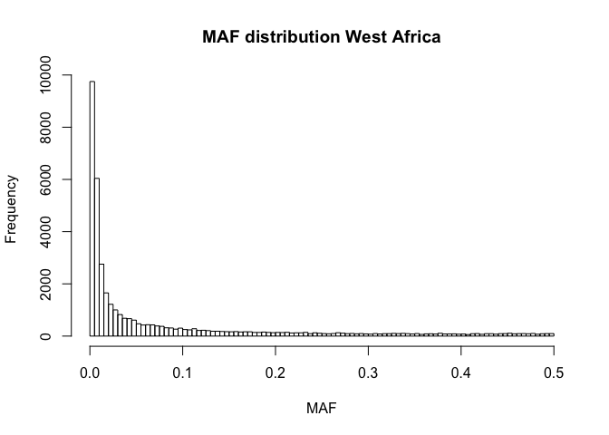

```
##
##
## chr           snp_functional_class    gene_biotype         n
## ------------  ----------------------  ---------------  -----
## Pf3D7_01_v3   INTERGENIC              NA                 149
## Pf3D7_01_v3   INTRAGENIC              NA                 129
## Pf3D7_01_v3   INTRON                  protein_coding      31
## Pf3D7_01_v3   NON_SYNONYMOUS_CODING   protein_coding     562
## Pf3D7_01_v3   STOP_GAINED             protein_coding       3
## Pf3D7_01_v3   STOP_LOST               protein_coding       1
## Pf3D7_01_v3   SYNONYMOUS_CODING       protein_coding     236
## Pf3D7_01_v3   SYNONYMOUS_STOP         protein_coding       1
## Pf3D7_01_v3   NA                      NA                   4
## Pf3D7_02_v3   INTERGENIC              NA                 191
## Pf3D7_02_v3   INTRAGENIC              NA                  60
## Pf3D7_02_v3   INTRON                  protein_coding      54
## Pf3D7_02_v3   NON_SYNONYMOUS_CODING   protein_coding     719
## Pf3D7_02_v3   NON_SYNONYMOUS_START    protein_coding       1
## Pf3D7_02_v3   STOP_GAINED             protein_coding       4
## Pf3D7_02_v3   SYNONYMOUS_CODING       protein_coding     365
## Pf3D7_02_v3   NA                      NA                   7
## Pf3D7_03_v3   INTERGENIC              NA                 218
## Pf3D7_03_v3   INTRAGENIC              NA                   4
## Pf3D7_03_v3   INTRON                  protein_coding      66
## Pf3D7_03_v3   NON_SYNONYMOUS_CODING   protein_coding     856
## Pf3D7_03_v3   START_LOST              protein_coding       1
## Pf3D7_03_v3   STOP_GAINED             protein_coding       1
## Pf3D7_03_v3   SYNONYMOUS_CODING       protein_coding     407
## Pf3D7_03_v3   SYNONYMOUS_STOP         protein_coding       1
## Pf3D7_04_v3   INTERGENIC              NA                 435
## Pf3D7_04_v3   INTRAGENIC              NA                 359
## Pf3D7_04_v3   INTRON                  protein_coding      89
## Pf3D7_04_v3   NON_SYNONYMOUS_CODING   protein_coding    1181
## Pf3D7_04_v3   START_LOST              protein_coding       1
## Pf3D7_04_v3   STOP_GAINED             protein_coding       5
## Pf3D7_04_v3   SYNONYMOUS_CODING       protein_coding     532
## Pf3D7_05_v3   INTERGENIC              NA                 504
## Pf3D7_05_v3   INTRAGENIC              NA                  36
## Pf3D7_05_v3   INTRON                  protein_coding     103
## Pf3D7_05_v3   NON_SYNONYMOUS_CODING   protein_coding    1099
```

[output cut: 65 more lines]

```
## Pf3D7_13_v3   STOP_GAINED             protein_coding       7
## Pf3D7_13_v3   SYNONYMOUS_CODING       protein_coding    1074
## Pf3D7_13_v3   SYNONYMOUS_STOP         protein_coding       1
## Pf3D7_13_v3   NA                      NA                   1
## Pf3D7_14_v3   INTERGENIC              NA                1314
## Pf3D7_14_v3   INTRAGENIC              NA                  71
## Pf3D7_14_v3   INTRON                  protein_coding     243
## Pf3D7_14_v3   NON_SYNONYMOUS_CODING   protein_coding    2824
## Pf3D7_14_v3   STOP_GAINED             protein_coding       6
## Pf3D7_14_v3   SYNONYMOUS_CODING       protein_coding    1219
## Pf3D7_14_v3   SYNONYMOUS_STOP         protein_coding       3
## Pf3D7_14_v3   NA                      NA                  10
## # of selected samples: 943
## # of selected variants: 30,498
## ## SE Asia
```

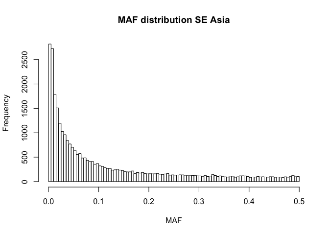

```
##
##
## chr           snp_functional_class    gene_biotype         n
## ------------  ----------------------  ---------------  -----
## Pf3D7_01_v3   INTERGENIC              NA                 205
## Pf3D7_01_v3   INTRAGENIC              NA                 130
## Pf3D7_01_v3   INTRON                  protein_coding      37
## Pf3D7_01_v3   NON_SYNONYMOUS_CODING   protein_coding     465
## Pf3D7_01_v3   STOP_GAINED             protein_coding       2
## Pf3D7_01_v3   SYNONYMOUS_CODING       protein_coding     206
## Pf3D7_01_v3   NA                      NA                   4
## Pf3D7_02_v3   INTERGENIC              NA                 378
## Pf3D7_02_v3   INTRAGENIC              NA                  55
## Pf3D7_02_v3   INTRON                  protein_coding      59
## Pf3D7_02_v3   NON_SYNONYMOUS_CODING   protein_coding     493
## Pf3D7_02_v3   STOP_GAINED             protein_coding       1
## Pf3D7_02_v3   SYNONYMOUS_CODING       protein_coding     237
## Pf3D7_02_v3   NA                      NA                   2
## Pf3D7_03_v3   INTERGENIC              NA                 345
## Pf3D7_03_v3   INTRAGENIC              NA                   3
## Pf3D7_03_v3   INTRON                  protein_coding      74
## Pf3D7_03_v3   NON_SYNONYMOUS_CODING   protein_coding     618
## Pf3D7_03_v3   STOP_GAINED             protein_coding       1
## Pf3D7_03_v3   SYNONYMOUS_CODING       protein_coding     327
## Pf3D7_04_v3   INTERGENIC              NA                 685
## Pf3D7_04_v3   INTRAGENIC              NA                 322
## Pf3D7_04_v3   INTRON                  protein_coding      91
## Pf3D7_04_v3   NON_SYNONYMOUS_CODING   protein_coding     936
## Pf3D7_04_v3   STOP_GAINED             protein_coding       3
## Pf3D7_04_v3   SYNONYMOUS_CODING       protein_coding     412
## Pf3D7_05_v3   INTERGENIC              NA                 540
## Pf3D7_05_v3   INTRAGENIC              NA                  38
## Pf3D7_05_v3   INTRON                  protein_coding      77
## Pf3D7_05_v3   NON_SYNONYMOUS_CODING   protein_coding     717
## Pf3D7_05_v3   SPLICE_SITE_DONOR       protein_coding       1
## Pf3D7_05_v3   STOP_GAINED             protein_coding       5
## Pf3D7_05_v3   STOP_LOST               protein_coding       1
## Pf3D7_05_v3   SYNONYMOUS_CODING       protein_coding     307
## Pf3D7_05_v3   NA                      NA                   7
## Pf3D7_06_v3   INTERGENIC              NA                 372
```

[output cut: 59 more lines]

```
## Pf3D7_13_v3   STOP_LOST               protein_coding       1
## Pf3D7_13_v3   SYNONYMOUS_CODING       protein_coding     646
## Pf3D7_13_v3   SYNONYMOUS_STOP         protein_coding       1
## Pf3D7_13_v3   NA                      NA                   2
## Pf3D7_14_v3   INTERGENIC              NA                1380
## Pf3D7_14_v3   INTRAGENIC              NA                 109
## Pf3D7_14_v3   INTRON                  protein_coding     187
## Pf3D7_14_v3   NON_SYNONYMOUS_CODING   protein_coding    1921
## Pf3D7_14_v3   STOP_GAINED             protein_coding       6
## Pf3D7_14_v3   SYNONYMOUS_CODING       protein_coding     780
## Pf3D7_14_v3   SYNONYMOUS_STOP         protein_coding       1
## Pf3D7_14_v3   NA                      NA                   8
## # of selected samples: 461
## # of selected variants: 53,300
## ## Central Africa
```

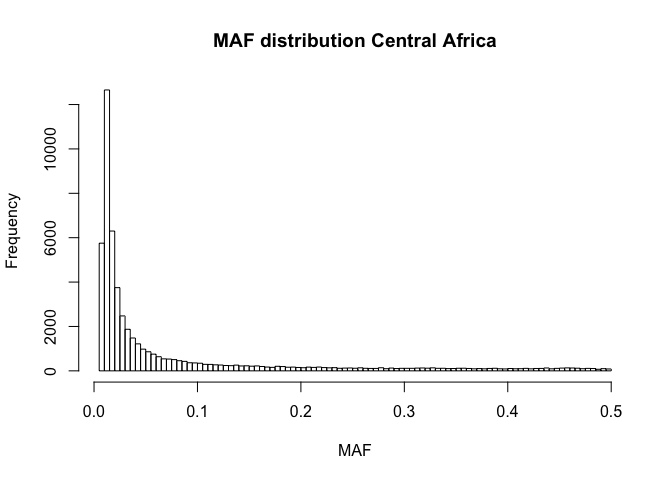

```
##
##
## chr           snp_functional_class    gene_biotype         n
## ------------  ----------------------  ---------------  -----
## Pf3D7_01_v3   INTERGENIC              NA                 337
## Pf3D7_01_v3   INTRAGENIC              NA                 144
## Pf3D7_01_v3   INTRON                  protein_coding      47
## Pf3D7_01_v3   NON_SYNONYMOUS_CODING   protein_coding     618
## Pf3D7_01_v3   STOP_GAINED             protein_coding       4
## Pf3D7_01_v3   SYNONYMOUS_CODING       protein_coding     293
## Pf3D7_01_v3   NA                      NA                   5
## Pf3D7_02_v3   INTERGENIC              NA                 590
## Pf3D7_02_v3   INTRAGENIC              NA                  79
## Pf3D7_02_v3   INTRON                  protein_coding      77
## Pf3D7_02_v3   NON_SYNONYMOUS_CODING   protein_coding     862
## Pf3D7_02_v3   NON_SYNONYMOUS_START    protein_coding       1
## Pf3D7_02_v3   STOP_GAINED             protein_coding       4
## Pf3D7_02_v3   SYNONYMOUS_CODING       protein_coding     375
## Pf3D7_02_v3   NA                      NA                  10
## Pf3D7_03_v3   INTERGENIC              NA                 573
## Pf3D7_03_v3   INTRAGENIC              NA                   4
## Pf3D7_03_v3   INTRON                  protein_coding     119
## Pf3D7_03_v3   NON_SYNONYMOUS_CODING   protein_coding     897
## Pf3D7_03_v3   STOP_GAINED             protein_coding       1
## Pf3D7_03_v3   SYNONYMOUS_CODING       protein_coding     490
## Pf3D7_03_v3   SYNONYMOUS_STOP         protein_coding       3
## Pf3D7_04_v3   INTERGENIC              NA                1063
## Pf3D7_04_v3   INTRAGENIC              NA                 413
## Pf3D7_04_v3   INTRON                  protein_coding     149
## Pf3D7_04_v3   NON_SYNONYMOUS_CODING   protein_coding    1368
## Pf3D7_04_v3   START_LOST              protein_coding       1
## Pf3D7_04_v3   STOP_GAINED             protein_coding       5
## Pf3D7_04_v3   SYNONYMOUS_CODING       protein_coding     646
## Pf3D7_05_v3   INTERGENIC              NA                 958
## Pf3D7_05_v3   INTRAGENIC              NA                  45
## Pf3D7_05_v3   INTRON                  protein_coding     142
## Pf3D7_05_v3   NON_SYNONYMOUS_CODING   protein_coding    1360
## Pf3D7_05_v3   SPLICE_SITE_DONOR       protein_coding       1
## Pf3D7_05_v3   STOP_GAINED             protein_coding       3
## Pf3D7_05_v3   STOP_LOST               protein_coding       1
```

[output cut: 60 more lines]

```
## Pf3D7_13_v3   NON_SYNONYMOUS_CODING   protein_coding    2907
## Pf3D7_13_v3   STOP_GAINED             protein_coding       6
## Pf3D7_13_v3   SYNONYMOUS_CODING       protein_coding    1333
## Pf3D7_13_v3   SYNONYMOUS_STOP         protein_coding       2
## Pf3D7_13_v3   NA                      NA                   1
## Pf3D7_14_v3   INTERGENIC              NA                2443
## Pf3D7_14_v3   INTRAGENIC              NA                 131
## Pf3D7_14_v3   INTRON                  protein_coding     375
## Pf3D7_14_v3   NON_SYNONYMOUS_CODING   protein_coding    3444
## Pf3D7_14_v3   START_LOST              protein_coding       3
## Pf3D7_14_v3   STOP_GAINED             protein_coding      11
## Pf3D7_14_v3   STOP_LOST               protein_coding       1
## Pf3D7_14_v3   SYNONYMOUS_CODING       protein_coding    1616
## Pf3D7_14_v3   SYNONYMOUS_STOP         protein_coding       1
## Pf3D7_14_v3   NA                      NA                  23
```

```r
# extract Fws metric
by_region_fws <- lapply(mgen_stats, function(country_list) data.frame(fws = unlist(lapply(country_list,
                                                                  function(info) info$fws))))
by_region_fws <- lapply(by_region_fws, function(x)  add_rownames(x, var = "id") %>%
                          tidyr::separate(id, c("country", "sample.id"), "(\\.)(.*?)", extra = "merge"))
# filter out Nigeria
by_region_fws[[1]] <- filter(by_region_fws[[1]], country != "Nigeria")

# save mafs, annotations, Fws values in  list of data.frames
# extract PED and map files as well
for (region in unique(field_isolates$region)) {
  # subset
  seqSetFilter(mgen,
               sample.id = by_region_samples[[region]],
               variant.id = by_region_snps[[region]])
  maf_by_region <- getMAF(mgen)

  cat(paste("##", region))

  hist(maf_by_region, breaks = 100,
       xlab = "MAF",
       main = paste("MAF distribution", region))

  # extract annotations for the subset
  annotations <- data.frame(chr = seqGetData(mgen, "chromosome"),
                          pos = seqGetData(mgen, "position"),
                          variant_id = seqGetData(mgen, "variant.id"),
                          gene_name = seqGetData(mgen, "annotation/info/SNPEFF_GENE_NAME"),
                          gene_biotype = seqGetData(mgen, "annotation/info/SNPEFF_GENE_BIOTYPE"),
                          snp_effect = seqGetData(mgen, "annotation/info/SNPEFF_AMINO_ACID_CHANGE"),
                          snp_functional_class = seqGetData(mgen, "annotation/info/SNPEFF_EFFECT"),
                          snp_aa_change = seqGetData(mgen, "annotation/info/SNPEFF_AMINO_ACID_CHANGE"),
                          snp_codon_change = seqGetData(mgen, "annotation/info/SNPEFF_CODON_CHANGE"),
                          exon_id = seqGetData(mgen, "annotation/info/SNPEFF_EXON_ID"),
                          transcript_id = seqGetData(mgen, "annotation/info/SNPEFF_TRANSCRIPT_ID"),
                          stringsAsFactors = FALSE)

  # recode missing '' as NA
  annotations[annotations == ''] <- NA
  # show annotation sets by chromosome

  print(knitr::kable(annotations %>%
                 count(chr, snp_functional_class, gene_biotype)))

  fws <- by_region_fws[[region]]
  # region summary
  region_summary <- list(maf = maf_by_region, annotations = annotations, fws = fws)
  write_rds(region_summary,
            paste0("processed_data/",
                   gsub(" ", "_", tolower(region)), "_summary.rds"))

  # extract PED
  region_plink <- extractPED(mgen, moi.estimates = ifelse(fws$fws > 0.95, 1, 2))
  write_rds(region_plink,
            paste0("processed_data/",
                   gsub(" ", "_", tolower(region)), "_ped.rds"))
  # extract genotypes / allele counts
  region_genotypes <- alleleCounts(mgen)
  write_rds(region_genotypes,
            paste0("processed_data/",
                   gsub(" ", "_", tolower(region)), "_acounts.rds"))

}
```

# 4 Appendix

```r
# tidy up gds
seqSetFilter(mgen)
```

```
## # of selected samples: 2,640
## # of selected variants: 1,057,870
```

```r
seqClose(mgen)
# cleanup.gds("processed_data/malaria_gen5.gds")
```